# BR Behavioral Quality Check

Dian Lu

29 May 2019

##### *Basic Behaviour Summary* (response and head movement)

### 1. Analysis of 3 kinds of percept

#### (1) For total conditions:

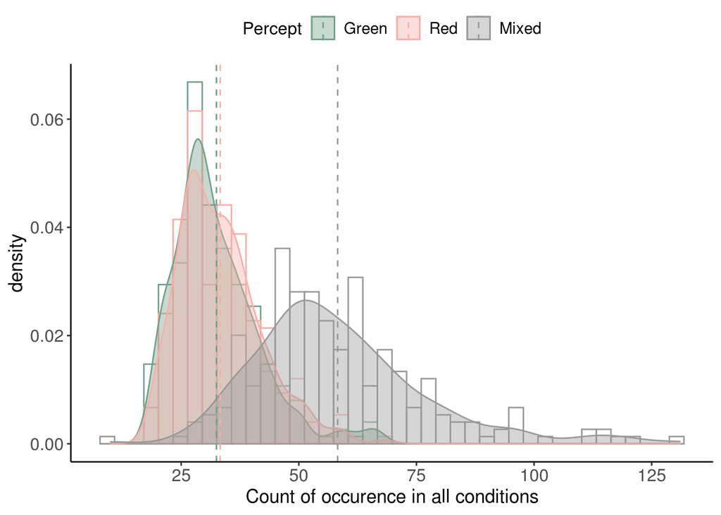

#### (2) For BR conditions:

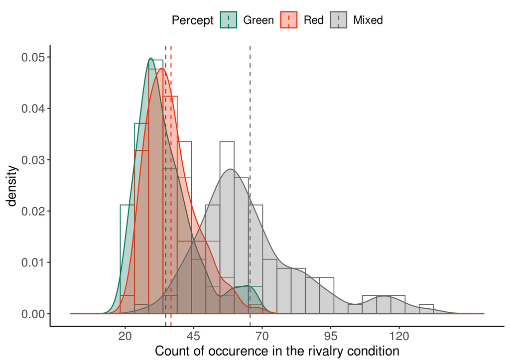

Conclusion: The mixed percept happens about twice as freqence as single percept (Red or Green), and the Red and Green percept happens with a almost equal frequency, because the red or green percept regularly alters to the other type via the transition of a mixed percept.

### (3) Comapring between conditions:

There are four conditions (Rival, Relay, Relay smooth, and Relay instantanous) randomly distributed across the 12-13 scans (one condition per scan) for each person. Are the conditions comparable?

```
## Linear mixed model fit by REML. t-tests use Satterthwaite's method [
## lmerModLmerTest]
## Formula: ALT_RATE ~ SCAN + gr_rate + (1 | SUB)
##    Data: bhv_new
##
## REML criterion at convergence: 188.9
##
## Scaled residuals:
##      Min       1Q   Median       3Q      Max
## -2.99604 -0.49190 -0.05537  0.45081  2.50650
##
## Random effects:
##  Groups   Name        Variance Std.Dev.
##  SUB      (Intercept) 0.07621  0.2761
##  Residual             0.09409  0.3067
## Number of obs: 241, groups:  SUB, 20
##
## Fixed effects:
##              Estimate Std. Error        df t value Pr(>|t|)
## (Intercept)   1.08443    0.22759 220.32772   4.765 3.43e-06 ***
## SCANscan10    0.36901    0.09996 204.03127   3.692 0.000286 ***
## SCANscan11    0.44963    0.10210 204.39511   4.404 1.72e-05 ***
## SCANscan12    0.38192    0.10348 204.26646   3.691 0.000287 ***
## SCANscan13    0.31064    0.15690 205.61274   1.980 0.049049 *
## SCANscan14    0.57504    0.23432 205.91612   2.454 0.014957 *
## SCANscan15    0.43370    0.32430 206.13735   1.337 0.182580
## SCANscan16    0.46669    0.32431 206.14218   1.439 0.151660
## SCANscan17    0.88824    0.32884 205.82717   2.701 0.007486 **
## SCANscan2     0.48170    0.09700 203.71965   4.966 1.44e-06 ***
## SCANscan3     0.13827    0.09704 203.73155   1.425 0.155703
## SCANscan4     0.25424    0.09702 203.72455   2.621 0.009440 **
## SCANscan5     0.18376    0.09703 203.72808   1.894 0.059659 .
## SCANscan6     0.37254    0.09703 203.72830   3.839 0.000165 ***
## SCANscan7     0.29255    0.09701 203.72173   3.016 0.002891 **
## SCANscan8     0.31348    0.09701 203.72123   3.231 0.001436 **
## SCANscan9     0.34084    0.09700 203.72017   3.514 0.000544 ***
## gr_rate       0.36248    0.21390 217.43521   1.695 0.091575 .
## ---
## Signif. codes:  0 '***' 0.001 '**' 0.01 '*' 0.05 '.' 0.1 ' ' 1
```

```
## Linear mixed model fit by REML ['lmerModLmerTest']
## Formula: ALT_RATE ~ SCAN + gr_rate + (1 | SUB)
##    Data: bhv_new
## REML criterion at convergence: 188.9462
## Random effects:
##  Groups   Name        Std.Dev.
##  SUB      (Intercept) 0.2761
##  Residual             0.3067
## Number of obs: 241, groups:  SUB, 20
## Fixed Effects:
## (Intercept)   SCANscan10   SCANscan11   SCANscan12   SCANscan13   SCANscan14
##      1.0844       0.3690       0.4496       0.3819       0.3106       0.5750
##  SCANscan15   SCANscan16   SCANscan17    SCANscan2    SCANscan3    SCANscan4
##      0.4337       0.4667       0.8882       0.4817       0.1383       0.2542
##   SCANscan5    SCANscan6    SCANscan7    SCANscan8    SCANscan9      gr_rate
##      0.1838       0.3725       0.2925       0.3135       0.3408       0.3625
```

```
## [1] "(1) Rival condition:"
```

```
##      SUB                SCAN              ALT_RATE         ALT_VAR
##  Length:109         Length:109         Min.   :0.7665   Min.   :0.4041
##  Class :character   Class :character   1st Qu.:1.3821   1st Qu.:1.2550
##  Mode  :character   Mode  :character   Median :1.6407   Median :1.4706
##                                        Mean   :1.6001   Mean   :1.5024
##                                        3rd Qu.:1.8450   3rd Qu.:1.7191
##                                        Max.   :2.5433   Max.   :2.5190
##      FREQ1           FREQ2           FREQ3           gr_rate
##  Min.   :20.00   Min.   :22.00   Min.   : 28.00   Min.   :0.6286
##  1st Qu.:28.00   1st Qu.:30.00   1st Qu.: 53.00   1st Qu.:0.8148
##  Median :32.00   Median :35.00   Median : 61.00   Median :0.9655
##  Mean   :34.79   Mean   :36.72   Mean   : 65.58   Mean   :0.9465
##  3rd Qu.:39.00   3rd Qu.:42.00   3rd Qu.: 71.00   3rd Qu.:1.0513
##  Max.   :67.00   Max.   :68.00   Max.   :131.00   Max.   :1.3200
##   CONDITION
##  Length:109
##  Class :character
##  Mode  :character
##
##
##
```

```
## [1] "(2) Relay inst. condition:"
```

```
##      SUB                SCAN              ALT_RATE        ALT_VAR
##  Length:36          Length:36          Min.   :1.014   Min.   :1.064
##  Class :character   Class :character   1st Qu.:1.569   1st Qu.:1.883
##  Mode  :character   Mode  :character   Median :1.847   Median :2.108
##                                        Mean   :1.857   Mean   :2.144
##                                        3rd Qu.:2.010   3rd Qu.:2.488
##                                        Max.   :2.813   Max.   :3.014
##      FREQ1           FREQ2           FREQ3          gr_rate
##  Min.   :20.00   Min.   :21.00   Min.   :27.00   Min.   :0.9032
##  1st Qu.:26.75   1st Qu.:26.00   1st Qu.:39.75   1st Qu.:0.9744
##  Median :29.00   Median :30.00   Median :47.00   Median :1.0000
##  Mean   :30.83   Mean   :30.83   Mean   :49.94   Mean   :1.0016
##  3rd Qu.:35.25   3rd Qu.:34.00   3rd Qu.:56.25   3rd Qu.:1.0288
##  Max.   :50.00   Max.   :53.00   Max.   :97.00   Max.   :1.1200
##   CONDITION
##  Length:36
##  Class :character
##  Mode  :character
##
##
##
```

```
## [1] "(3) Relay smooth. condition:"
```

```
##      SUB                SCAN              ALT_RATE        ALT_VAR
##  Length:95          Length:95          Min.   :1.036   Min.   :0.8277
##  Class :character   Class :character   1st Qu.:1.500   1st Qu.:1.6891
##  Mode  :character   Mode  :character   Median :1.773   Median :1.9484
##                                        Mean   :1.820   Mean   :2.0225
##                                        3rd Qu.:2.035   3rd Qu.:2.4767
##                                        Max.   :2.754   Max.   :2.7861
##      FREQ1           FREQ2           FREQ3          gr_rate
##  Min.   :19.00   Min.   :20.00   Min.   :10.00   Min.   :0.9048
##  1st Qu.:25.50   1st Qu.:25.00   1st Qu.:45.50   1st Qu.:0.9615
##  Median :29.00   Median :28.00   Median :51.00   Median :1.0000
##  Mean   :30.56   Mean   :30.35   Mean   :53.36   Mean   :1.0088
##  3rd Qu.:35.00   3rd Qu.:36.00   3rd Qu.:62.50   3rd Qu.:1.0446
##  Max.   :51.00   Max.   :51.00   Max.   :96.00   Max.   :1.1852
##   CONDITION
##  Length:95
##  Class :character
##  Mode  :character
##
##
##
```

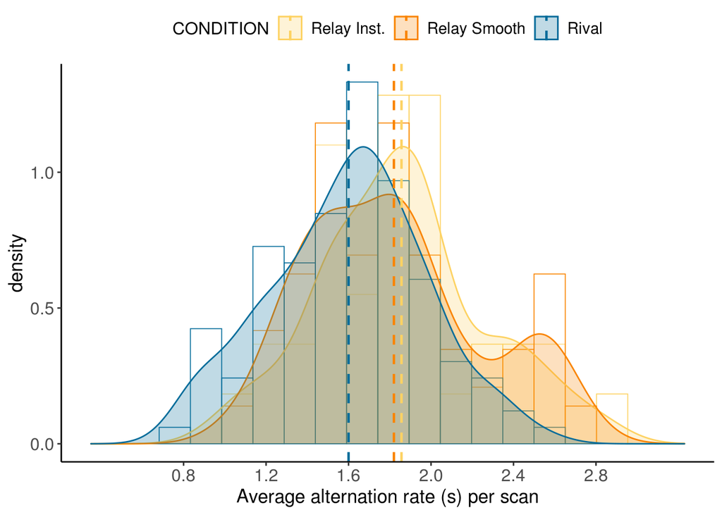

```
## Linear mixed model fit by REML. t-tests use Satterthwaite's method [
## lmerModLmerTest]
## Formula: ALT_RATE ~ SCAN + CONDITION + gr_rate + (1 | SUB)
##    Data: scandata
##
## REML criterion at convergence: 186.1
##
## Scaled residuals:
##      Min       1Q   Median       3Q      Max
## -3.07812 -0.50840 -0.06965  0.49935  2.67484
##
## Random effects:
##  Groups   Name        Variance Std.Dev.
##  SUB      (Intercept) 0.06893  0.2626
##  Residual             0.09127  0.3021
## Number of obs: 240, groups:  SUB, 20
##
## Fixed effects:
##                        Estimate Std. Error        df t value Pr(>|t|)
## (Intercept)             1.49222    0.26326 219.56506   5.668 4.51e-08 ***
## SCANscan10              0.26280    0.10391 201.18066   2.529 0.012199 *
## SCANscan11              0.34585    0.10652 201.15238   3.247 0.001367 **
## SCANscan12              0.25462    0.11241 201.62487   2.265 0.024566 *
## SCANscan13              0.18696    0.16020 203.14286   1.167 0.244572
## SCANscan14              0.49334    0.23408 203.36382   2.108 0.036289 *
## SCANscan15              0.25948    0.32484 203.85722   0.799 0.425342
## SCANscan16              0.25958    0.33035 204.12710   0.786 0.432899
## SCANscan17              0.93527    0.32448 202.91435   2.882 0.004373 **
## SCANscan2               0.39161    0.10127 201.08411   3.867 0.000149 ***
## SCANscan3               0.10764    0.09624 200.78097   1.119 0.264685
## SCANscan4               0.17357    0.10021 200.92422   1.732 0.084778 .
## SCANscan5               0.15191    0.09631 200.69486   1.577 0.116312
## SCANscan6               0.28034    0.10153 201.19331   2.761 0.006293 **
## SCANscan7               0.25784    0.09628 200.71154   2.678 0.008016 **
## SCANscan8               0.22146    0.10046 201.08501   2.204 0.028631 *
## SCANscan9               0.23909    0.10186 201.13791   2.347 0.019883 *
## CONDITIONRelay Smooth  -0.03248    0.06842 201.72318  -0.475 0.635545
## CONDITIONRival         -0.17027    0.07279 203.19711  -2.339 0.020297 *
## gr_rate                 0.11120    0.22734 216.63414   0.489 0.625253
## ---
## Signif. codes:  0 '***' 0.001 '**' 0.01 '*' 0.05 '.' 0.1 ' ' 1
```

```
## Linear mixed model fit by REML ['lmerModLmerTest']
## Formula: ALT_RATE ~ SCAN + CONDITION + gr_rate + (1 | SUB)
##    Data: scandata
## REML criterion at convergence: 186.0979
## Random effects:
##  Groups   Name        Std.Dev.
##  SUB      (Intercept) 0.2626
##  Residual             0.3021
## Number of obs: 240, groups:  SUB, 20
## Fixed Effects:
##           (Intercept)             SCANscan10             SCANscan11
##               1.49222                0.26280                0.34585
##            SCANscan12             SCANscan13             SCANscan14
##               0.25462                0.18696                0.49334
##            SCANscan15             SCANscan16             SCANscan17
##               0.25948                0.25958                0.93527
##             SCANscan2              SCANscan3              SCANscan4
##               0.39161                0.10764                0.17357
##             SCANscan5              SCANscan6              SCANscan7
##               0.15191                0.28034                0.25784
##             SCANscan8              SCANscan9  CONDITIONRelay Smooth
##               0.22146                0.23909               -0.03248
##        CONDITIONRival                gr_rate
##              -0.17027                0.11120
```

```
## Linear mixed model fit by REML. t-tests use Satterthwaite's method [
## lmerModLmerTest]
## Formula: ALT_RATE ~ (1 | SCAN) + CONDITION + gr_rate + (1 | SUB)
##    Data: scandata
##
## REML criterion at convergence: 171.9
##
## Scaled residuals:
##     Min      1Q  Median      3Q     Max
## -3.0787 -0.4570 -0.0949  0.5404  2.7544
##
## Random effects:
##  Groups   Name        Variance Std.Dev.
##  SUB      (Intercept) 0.06781  0.26041
##  SCAN     (Intercept) 0.00525  0.07246
##  Residual             0.09206  0.30342
## Number of obs: 240, groups:  SUB, 20; SCAN, 17
##
## Fixed effects:
##                        Estimate Std. Error        df t value Pr(>|t|)
## (Intercept)             1.68900    0.23457 232.80924   7.200 8.23e-12 ***
## CONDITIONRelay Smooth  -0.04488    0.06297 199.77258  -0.713   0.4769
## CONDITIONRival         -0.21019    0.06472 170.13342  -3.248   0.0014 **
## gr_rate                 0.16752    0.21910 228.98766   0.765   0.4453
## ---
## Signif. codes:  0 '***' 0.001 '**' 0.01 '*' 0.05 '.' 0.1 ' ' 1
##
## Correlation of Fixed Effects:
##             (Intr) CONDIS CONDIT
## CONDITIONRS -0.167
## CONDITIONRv -0.393  0.721
## gr_rate     -0.938 -0.028  0.213
```

```
## Linear mixed model fit by REML ['lmerModLmerTest']
## Formula: ALT_RATE ~ (1 | SCAN) + CONDITION + gr_rate + (1 | SUB)
##    Data: scandata
## REML criterion at convergence: 171.9449
## Random effects:
##  Groups   Name        Std.Dev.
##  SUB      (Intercept) 0.26041
##  SCAN     (Intercept) 0.07246
##  Residual             0.30342
## Number of obs: 240, groups:  SUB, 20; SCAN, 17
## Fixed Effects:
##           (Intercept)  CONDITIONRelay Smooth         CONDITIONRival
##               1.68900               -0.04488               -0.21019
##               gr_rate
##               0.16752
```

Conclusion: Between-scan variance is absorbed by the difference of the rival condition comparing to other conditions. The alternation rate is significantly quicker (t = -3.25, p = 0.0014) in the rival condition (mean = 1.6s) than the relay inst. condition (mean = 1.85s) or the relay smooth condition (mean = 1.82s). However, there is no difference in alternation rate between red and green percept.

##### (3.1) Percept alternation rate per scan during the Rivalry condition

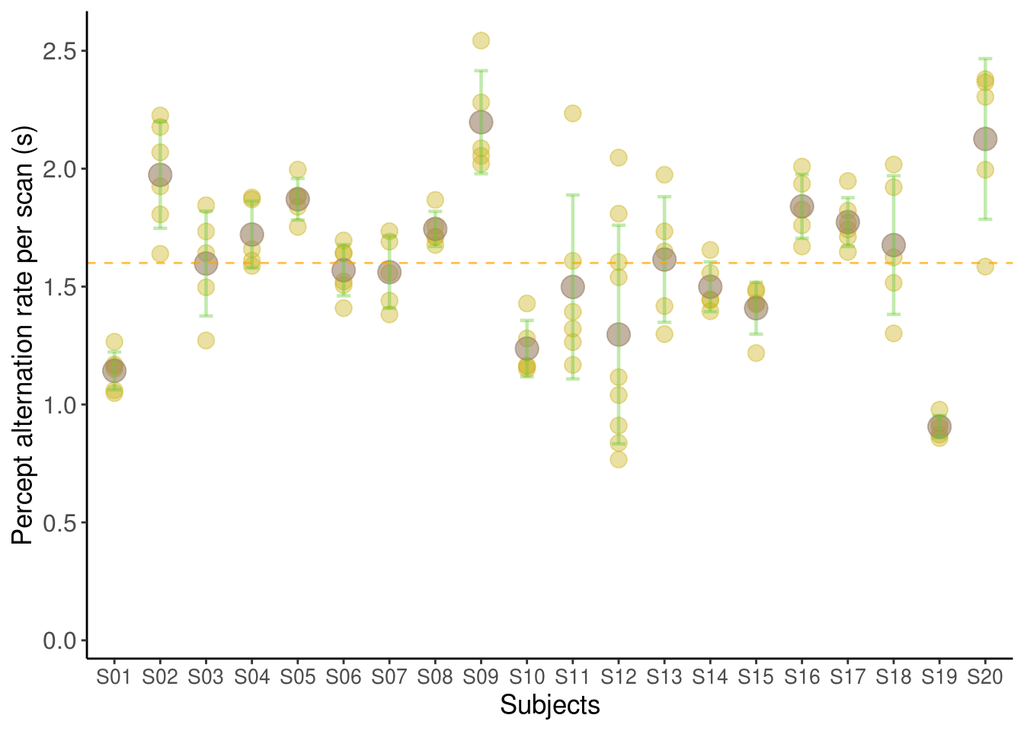

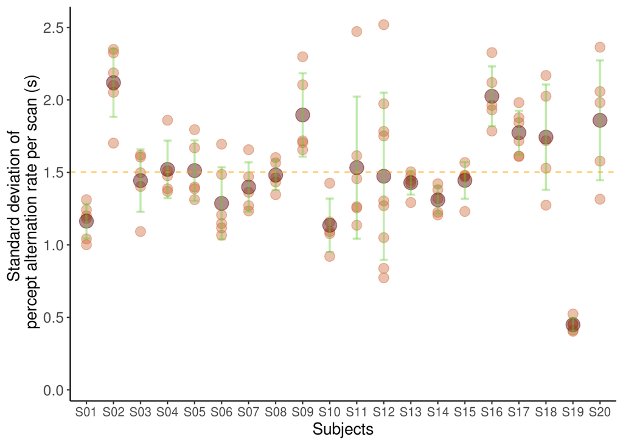

##### (3.2) The relationship between the alternation rate and stableness of the alternation

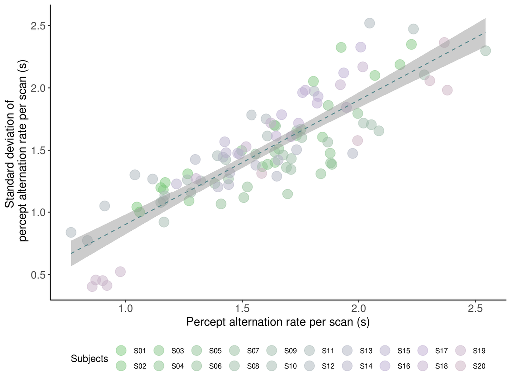

#### (4) Comparing between the duration of the three types of percept during BR

```
## [1] "Summary of the trial_by_trial percept duration."
```

```
##      SUBS              SCANS            CONDITION          TRIAL_INFO
##  Length:14398       Length:14398       Length:14398       Length:14398
##  Class :character   Class :character   Class :character   Class :character
##  Mode  :character   Mode  :character   Mode  :character   Mode  :character
##
##
##
##    ALT_DELAY         ALT_PERCEPT      Percept
##  Min.   : 0.01611   Min.   :1.000   Length:14398
##  1st Qu.: 0.29999   1st Qu.:2.000   Class :character
##  Median : 1.00006   Median :2.000   Mode  :character
##  Mean   : 1.49793   Mean   :2.238
##  3rd Qu.: 2.26568   3rd Qu.:3.000
##  Max.   :13.47731   Max.   :3.000
```

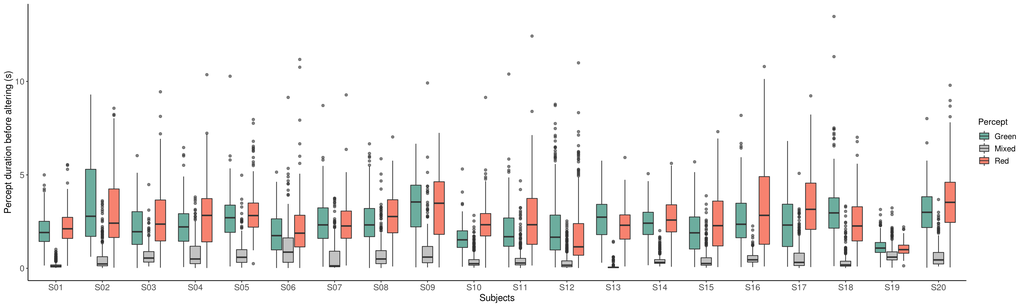

#### (5) Stats for individual difference of the BR

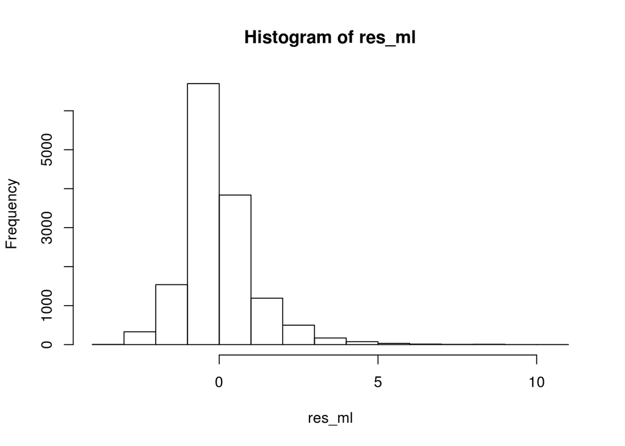

|  | Res.Df | RSS | Df | Sum of Sq | Pr(>Chi) |
| --- | --- | --- | --- | --- | --- |
| 1 | 14362 | 18850.88 | NA | NA | NA |
| 2 | 14381 | 20341.15 | -19 | -1490.265 | 6.197965e-229 |

```
## [1] "AIC is reduced by 1057.48693947027"
```

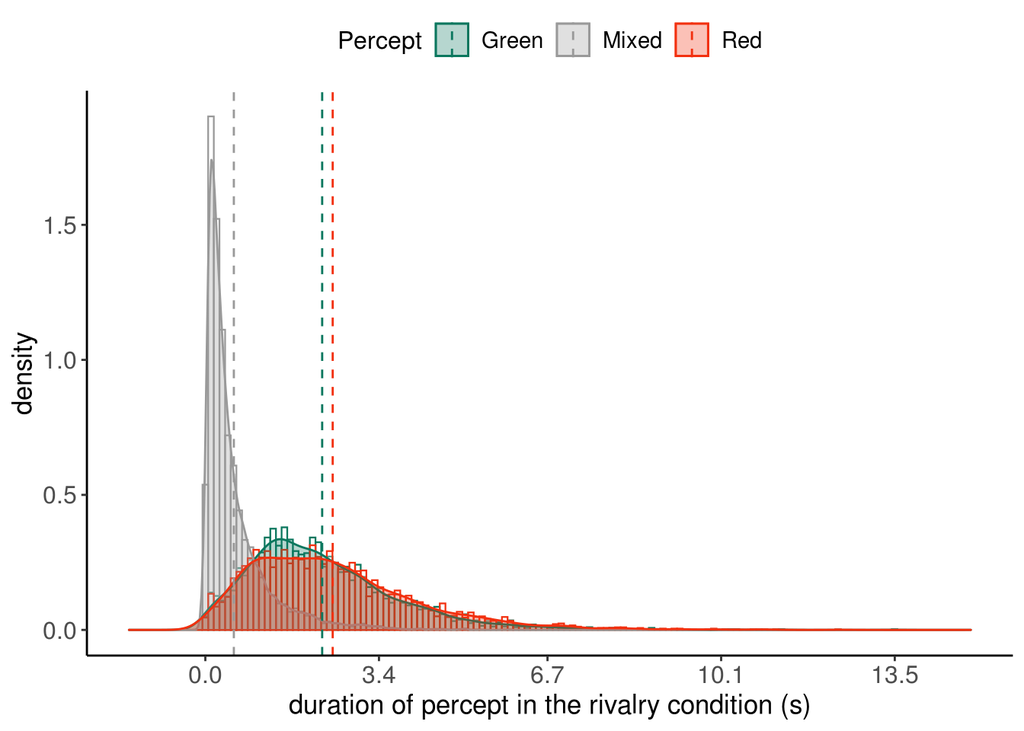

| .y. | group1 | group2 | p | p.adj | p.format | p.signif | method |
| --- | --- | --- | --- | --- | --- | --- | --- |
| ALT_DELAY | Rival | Relay Smooth | 8.444477e-09 | 8.4e-09 | 8.4e-09 | **** | Wilcoxon |
| ALT_DELAY | Rival | Relay Inst. | 9.352767e-25 | 2.8e-24 | < 2e-16 | **** | Wilcoxon |
| ALT_DELAY | Relay Smooth | Relay Inst. | 1.762662e-23 | 3.5e-23 | < 2e-16 | **** | Wilcoxon |

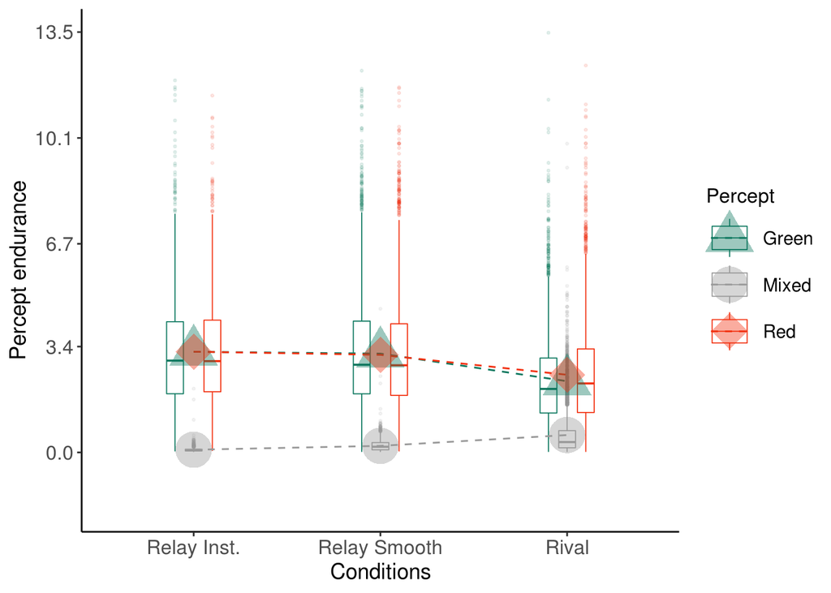

#### (6) Comparing between the duration of the BR mixed vs RPL Smooth mixed

|  | npar | AIC | BIC | logLik | deviance | Chisq | Df | Pr(>Chisq) |
| --- | --- | --- | --- | --- | --- | --- | --- | --- |
| mod0 | 3 | 18522.16 | 18544.36 | -9258.079 | 18516.16 | NA | NA | NA |
| mod1 | 5 | 16567.20 | 16604.20 | -8278.598 | 16557.20 | 1958.962 | 2 | 0 |

### 2. Head movement inspection

Set standards of outliers:

1. data-driven threshold to find out outlier scans:

(the group mean of individual’s average displacement + 3*SD) –> 0.998 mm (the group mean of individual’s maximal time-variant displacement + 1*SD –> 0.82 mm

i.e. if the scan (with time-series volumes) has an average displacement of head position bigger than 0.998 mm **OR** the maximum of time-variant displacement bigger than 0.82 mm, then it will be taken as an outlier scan and will be dealt with.

2. hard threshold from previous literature to find out outlier volumes for those outlier scans: 0.25 (+2S.D. for all displacements across all subjects) –> 0.2570 mm

What are the outliers scans?

|  | subject | scan |
| --- | --- | --- |
| X33 | S01 | scan12 |
| X34 | S01 | scan13 |
| X213 | S02 | scan1 |
| X316 | S02 | scan12 |
| X317 | S02 | scan2 |
| X223 | S02 | scan8 |
| X324 | S02 | scan9 |
| X357 | S05 | scan6 |
| X361 | S06 | scan1 |
| X363 | S06 | scan11 |

[output cut: 36 more lines]

An example of an extreme case of outlier: S07-scan 9

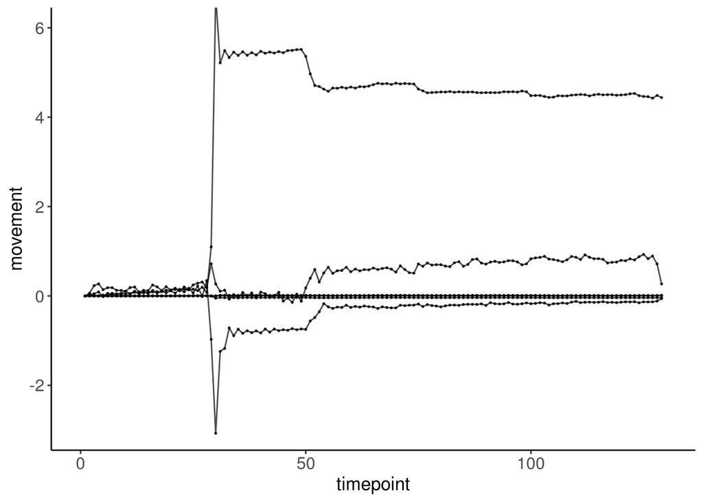

Summary & descriptions of the problematic volumes for those outliers scans

```
##     Subject         Run      Scan.with.spikes
##  S12    :283   scan11 :117   Min.   :  2.00
##  S06    :192   scan12 : 95   1st Qu.: 36.00
##  S07    :180   scan9  : 71   Median : 67.00
##  S02    :114   scan5  : 67   Mean   : 67.71
##  S01    : 23   scan7  : 67   3rd Qu.:101.00
##  S10    :  9   scan6  : 66   Max.   :129.00
##  (Other): 15   (Other):333
```

|  | vars | n | mean | sd | median | trimmed | mad | min | max | range | skew | kurtosis | se |
| --- | --- | --- | --- | --- | --- | --- | --- | --- | --- | --- | --- | --- | --- |
| Subject* | 1 | 816 | 4.943627 | 1.859945 | 5 | 5.077982 | 2.9652 | 1 | 8 | 7 | -0.35560167 | -0.9446602 | 0.06511109 |
| Run* | 2 | 816 | 7.457108 | 4.212820 | 7 | 7.321101 | 4.4478 | 1 | 17 | 16 | 0.16101260 | -0.7833463 | 0.14747819 |
| Scan.with.spikes | 3 | 816 | 67.709559 | 36.744887 | 67 | 67.981651 | 48.9258 | 2 | 129 | 127 | -0.02873909 | -1.0820961 | 1.28632833 |

What are the volumes that should be dealt with for those outliers scans?

```
## [1] "For S01 scan12 , 13 unsable volumes: 78,54,56,59,80,128,4,7,79,81,87,104,129"
## [1] "For S01 scan13 , 5 unsable volumes: 64,59,60,62,125"
## [1] "For S01 scan9 , 5 unsable volumes: 52,5,26,28,51"
## [1] "For S02 scan1 , 18 unsable volumes: 77,87,101,128,14,16,24,27,29,52,54,56,66,67,76,79,86,102"
## [1] "For S02 scan12 , 6 unsable volumes: 3,4,5,6,7,12"
## [1] "For S02 scan2 , 14 unsable volumes: 3,5,54,79,81,96,125,2,4,34,78,80,124,127"
## [1] "For S02 scan8 , 36 unsable volumes: 100,109,27,28,45,51,52,53,59,64,75,76,77,78,81,82,84,88,89,101,102,105,106,107,110,111,114,120,124,125,127,128,14,43,79,117"
## [1] "For S02 scan9 , 6 unsable volumes: 54,78,79,80,4,30"
## [1] "For S02 scan11 , 13 unsable volumes: 52,76,79,101,103,104,124,125,3,26,53,78,127"
## [1] "For S02 scan4 , 21 unsable volumes: 76,102,43,51,58,81,82,100,103,106,126,128,9,39,50,52,72,73,77,79,127"
## [1] "For S05 scan6 , 8 unsable volumes: 41,42,43,73,74,75,76,77"
## [1] "For S06 scan1 , 9 unsable volumes: 54,56,55,111,112,114,115,124,125"
## [1] "For S06 scan11 , 27 unsable volumes: 40,41,24,25,31,33,36,78,102,106,42,51,53,54,55,56,77,79,80,81,89,91,93,94,101,103,107"
## [1] "For S06 scan12 , 26 unsable volumes: 85,86,2,3,26,27,29,33,121,122,21,22,23,24,25,28,30,31,32,34,35,36,37,38,39,87"
## [1] "For S06 scan13 , 19 unsable volumes: 27,102,3,28,75,77,100,2,51,53,54,74,76,99,101,105,108,109,122"
```

[output cut: 31 more lines]

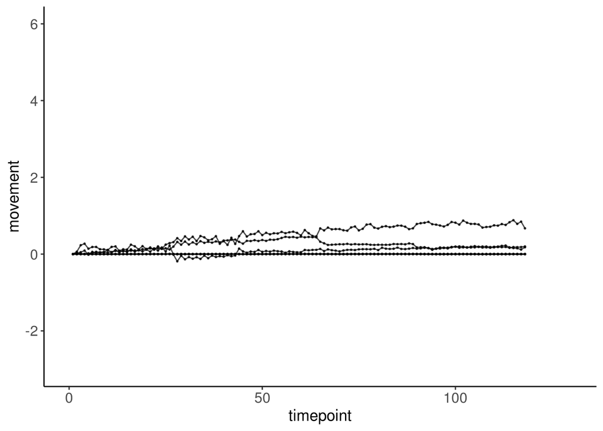